# ポートフォリオ最適化

このチュートリアルではポートフォリオ最適化を扱います。ポートフォリオとは株や債券などの金融商品の組み合わせのことです。金融商品に投資を行うことはリスクを伴いつつ確実な利益を狙うことと言えます。したがって、なるべくリスク抑えるために分散投資をしつつ利益の期待値を最大化するポートフォリオの最適化が必要になります。

[figure not shown]

## 定式化

今回は、過去の価格を格納したデータを用いて、リスクを抑えつつ、利益を最大化する平均分散モデルによってポートフォリオを求めます。

まず、利益とリスクを下記に定義します。

- 利益: 一定期間運用した場合の期待収益率
- リスク: ポートフォリオに含まれる銘柄間の値動きの相関 (共分散)

上記の二つの目的を同時に達成するための定式化に必要な定数・変数を定義します。

### 定数

$n$: 金融商品の総数、 $R_i$: 金融商品$i$の収益率、 $K$: 最大資産口数

### 変数

$w_i $: 金融商品$i$に投資する口数を表す非負変数

### 目的関数

この問題では、リスクを抑えつつ、利益を最大化することを目的関数として定式化します。

#### 期待収益率の最大化

期待収益率を最大化する式は、$E(\cdot)$を期待値として、 \begin{align*} \max_{{\bf w}} E_{{\bf w}}(R) \Leftrightarrow \max_{{\bf w} } \sum_{i=1}^n w_i E(R_i) \end{align*} と表されます。

#### ポートフォリオ収益の分散の最小化

ポートフォリオ収益の分散の最小化は、$Cov(\cdot, \cdot)$を共分散として、

\begin{align*} \min_{{\bf w}} V_{{\bf w}}(R) = \min_{{\bf w}} \sum_{i=1}^n \sum_{j=1}^n w_i w_j Cov(R_i, R_j) \end{align*} と表されます。

これら期待収益率の最大化とポートフォリオ収益の分散の最小化を目的関数とします。ポートフォリオ収益の分散を考慮する非負のパラメータを$\gamma $として、

\begin{align*} \max_{{\bf w} } E_{{\bf w}}(R) - \frac{\gamma}{2} V_{{\bf w}}(R) \end{align*}

として目的関数ができました。$\gamma=0$であれば、リスクを無視した利益追求型のポートフォリオが出力されることが期待されます。

### 制約式

最大で投資できる資産の口数は$K$であるため、各金融商品$i$に対する投資口数$w_i$の総和が$K$である必要があるため、制約式として表現します。

\begin{align*} \sum_{i=1}^n w_i = K \end{align*}

## 非負整数をバイナリ変数で表現する方法

ここまで、非負変数$w_i$を用いて記述してましたが、アニーリングマシンに入力するためには、非負変数をバイナリ変数で表現する必要があります。ここでは、非負変数をバイナリ変数で表現す方法を紹介します。

一般的には、非負変数$w_i$に対して、$D$次元バイナリベクトル${\bf x}_i$が存在し、 $$ w_i = \sum_{d=1}^D f(d) x_{id} $$ と表現できる関数$f$を定めます。$f$を定め方として次の**Unary法**が知られています。

### Unary法

Unary法では、$f$を次のように定めます。 $$ f(d)=1 $$

Unary法は最も単純な方法です。特性として、非負変数の最大値(定式化中の$K$)と同じだけのバイナリ変数が必要となり、変数が多くなる点が挙げられます。

このサンプルコードでは、Unary法を採用して実装を行います。

### まとめ

以上より、ポートフォリオ最適化問題は以下のように定式化されます。

\begin{matrix} \max & \displaystyle E_{{\bf w}}(R) - \frac{\gamma}{2} V_{{\bf w}}(R) \\ {\text{s.t}} & \displaystyle \sum_{i=1}^n w_i = K \\ & \displaystyle w_i = \sum_{d=1}^D f(d) x_{id}\\ & \displaystyle x_{id} \in \{0, 1\} \end{matrix}

## データの取得

### 入力データ

株価の時系列データは `pandas-datareader`[2] モジュールを使用して取得します。

### 各金融商品の収益率の計算方法

先程の定式化で使用している金融商品$i$の期待収益率$E(R_i)$と、金融商品$i,j$を同時に購入した際のポートフォリオ収益の分散$Cov(R_i, R_j)$を推定する方法について、ここで説明します。

ここでは、推定方法の１つである、ヒストリカルデータ方式について紹介[3]します。

#### ヒストリカルデータ方式

ヒストリカルデータ方式は、過去の価格データの平均値などを用いて資産の期待収益率を求める推定方法です。ある資産の価格データが、過去のデータと同じ値動きをする条件下では、信頼できる期待収益率の推定方法です。一方、過去データに外れ値が含まれていると、期待収益率の推定値の信頼性が低くなる可能性があります。

今回のサンプルコードではヒストリカルデータ方式を採用して、期待収益率とポートフォリオ収益の共分散を推定します。

株価データを読み込む関数を作成します。 今回使用するデータは次のようなcsvファイルとして事前に取得しています。 データの粒度は日単位です。

- `date`: 日付
- `High`: 高値
- `Low`: 安値
- `Open`: 始値
- `Close`: 終値
- `Volume`: ボリューム（取引数量）
- `Adj Close`: 調整後終値

をカラムとしてデータが格納されています。

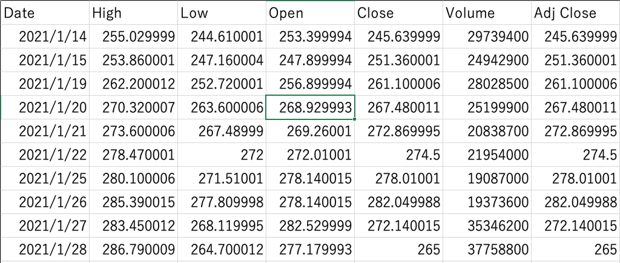

今回は、日単位での取引を前提にポートフォリオ最適化の入力データを作成します。日単位でのポートフォリオを作成するために、 ある日における**株の値段を高値と安値の平均値**とします。以下の関数は、`.csv`ファイルのあるディレクトリの`root`を指定して、それ以下に存在する`.csv`ファイルを読み込み、毎日の値動きを`numpy.array`に格納して返します。`.csv`ファイルの列挙には`glob`を用いており、`.csv`ファイルの読み込みには`pandas`を使用しています。

```python
import os
import glob

import pandas as pd
import numpy as np


def read_csv_data_yahoo(root):
    """
    Parameters
    ----------
    root: str
        データのあるディレクトリ名

    Returns
    -------
    asset: np.array
        銘柄と期間中のkeyの変動を格納した行列, shape is (num of brands, num of dates)
    """
    asset = list()
    paths = glob.glob(f"{root}/*.csv")
    for path in paths:
        df = pd.read_csv(
            path, index_col="Date", infer_datetime_format=True
        )  # showするならここに挿入
        df.index = pd.to_datetime(df.index)
        high_value = df["High"].to_numpy().reshape(1, -1)
        low_value = df["Low"].to_numpy().reshape(1, -1)

        # highとlowの平均値
        value = (high_value + low_value) * 0.5
        asset.append(value)

    dates = df.index.to_pydatetime()  # pandas.Timestamp → datetime
    asset = np.concatenate(asset, axis=0)

    names = [os.path.basename(path).replace(".csv", "") for path in paths]
    return asset, names, dates
```

### ヒストリカルデータ方式

ヒストリカルデータ方式では、過去データにおける収益率の平均を期待収益率として推定します。ここでは、具体的に期待収益率とリスク分散の計算方法について説明します。

ある金融商品$i$について、$N$日間の過去の値動きデータ$x_0, \cdots, x_{N-1}$が得られたとします。このとき$N$日以降の$D$日間のポートフォリオを考えます。  
まず、$D$日間の時系列データの組を作成します。

$$ \{(x_0, \cdots, x_{D-1}), (x_1, \cdots, x_D),\cdots, (x_{N-D}, \cdots, x_{N-1})\} $$

これらの組それぞれにおける収益率$\mu_{i, d}$を計算します。

各組で計算された収益率の平均を、この金融商品$i$における期待収益率$E(R_i)$とします。 $$ E(R_i) = \frac{1}{N-D+1} \sum_{d=0}^{N-D}\mu_{i, d} $$

実装では、$D$日間の収益率をリストに格納し、`numpy.array`として銘柄で結合(`numpy.concatenate`)します。期待収益率の計算では、銘柄ごとに収益率の平均を計算(`numpy.mean`)し、銘柄間の分散共分散は、`numpy.cov`を用いて計算しています。

```python
def historical_data_method(asset, D):
    """ヒストリカルデータ方式による期待収益率・分散の計算
    Parameters
    ----------
    asset: np.ndarray
        各銘柄の過去の価格値

    D: int
        投資して回収するまでの期間

    Returns
    -------
    expected_rate_of_return: array
        shape is (num of brands, N - D)
    covariance_rate_of_return; array
        shape is (num of brands, num of brands)
    """
    assert isinstance(D, int)
    _, N = asset.shape

    # N - Dまで欲しいので + 1
    list_rate_of_return_per_term = list()
    for j in range(N - D + 1):
        start = j
        end = j + D - 1
        rate_of_return = np.divide(
            asset[:, end] - asset[:, start], asset[:, start]
        ).reshape(-1, 1)
        list_rate_of_return_per_term.append(rate_of_return)

    rate_of_return_per_term = np.concatenate(list_rate_of_return_per_term, axis=1)

    # 各銘柄に対する期待収益率
    expected_rate_of_return = np.mean(rate_of_return_per_term, axis=1)

    # 銘柄間の共分散
    covariance_rate_of_return = np.cov(rate_of_return_per_term)

    return expected_rate_of_return, covariance_rate_of_return
```

## 定数の設定

定式化中の$K$と投資してから回収するまでの期間$D$日を定めます。ここでは回収するまでの期間を一週間($D=7$)とします。 また、定式化中のリスク分散を考慮するパラメータ$\gamma$を定めます。

その後、過去の価格データを格納しているcsvからデータを読み込み、ヒストリカルデータ方式で各銘柄の期待収益率とリスク分散を計算します。

```python
## 最大投資口数 K
K = 10

## 回収期間D
D = 7

## 共分散を考慮するパラメータ
gamma = 20
```

```python
# storage以下のデータの読み込み
asset, names, _ = read_csv_data_yahoo(root="../../../storage/portfolio")
num_brand, num_date = asset.shape

# ヒストリカルデータ方式による期待収益率とリスク分散の計算
expected_rate_of_return, variance_rate_of_return = historical_data_method(asset, D)
```

## 定式化実装

まず、銘柄$i$の投資口数を表す非負変数$w_i$を作成します。アニーリングマシンに入力するためには、非負変数をバイナリ変数で表現するために、 Unary法を用いて$w_i$を表現します。

$$ w_i = \sum_{d=1}^K x_{id} $$

まず、`BinarySymbolGenerator` クラスを用いて、銘柄$i$に対して$K$次元バイナリベクトル${\bf x}_i$を用意します。(`num_brand`$\times$`K`)の行列をイメージして頂ければわかりやすいと思います。

その後、銘柄$i$に対して$K$次元ベクトル${\bf x }_i$の全ての要素を足し合わせることで、非負変数$w_i$を配列として作成します。

```python
from amplify import BinarySymbolGenerator

# 変数の定義
x = BinarySymbolGenerator().array(num_brand, K)

# Unary法による非負整数wのバイナリ変数xによる表現
w = x.sum(axis=1)
```

### 目的関数の設定

次に目的関数を定義します。 目的関数は、期待収益率の最大化かつポートフォリオ収益の分の最小化です。ポートフォリオ収益の分を考慮する非負パラメータを$\gamma$として、 \begin{align*} &\max_{{\bf w} \in \mathbf{Z}^n_{\geq 0}} E_{{\bf w}}(R) - \frac{\gamma}{2} V_{{\bf w}}(R) = \sum_{i=1}^n w_i E(R_i) - \frac{\gamma}{2} \sum_{i=1}^n \sum_{j=1}^n w_i w_j Cov(R_i, R_j) \end{align*} と定式化されています。

ここでは、`einsum` 関数を用いて最もシンプルな形式で数式を記述しています。`einsum` 関数の詳細については [こちら](https://amplify.fixstars.com/docs/array.html#polynomial-array-einsum) を参照してください。数式と `einsum` 関数の引数を見比べると理解しやすいと思います。

最後に最大化問題を最小化問題に変換するため $(-1)$ 倍しています。

```python
from amplify import einsum


# 目的関数の定義
def setObjective(w, num_brand, expected_rate_of_return, variance_rate_of_return, gamma):
    """目的関数を定義
    ----------
    w: BinaryPolyArray
        各銘柄の購入口数を表す非負変数

    num_brand: int
        ポートフォリオを組む銘柄数

    expected_rate_of_return: np.ndarray
        期待収益率

    variance_rate_of_return: np.ndarray
        リスク分散

    gamma: float
        期待リスクの重要度を表すパラメータ

    Notes
    -----
    期待収益率の最大化と期待リスクの最小化
    期待収益率: E_w(R)
    期待リスク: V_w(R)
    目的関数 =  E_w(R) - gamma / 2 * V_w(R)
    """

    # 期待収益率の定義
    profit = einsum("i,i->", w, expected_rate_of_return)

    # 分散の定義
    risk = einsum("i,j,ij->", w, w, variance_rate_of_return)

    # 目的関数の定義
    objective = -profit + gamma * 0.5 * risk

    return objective, profit, risk
```

### 制約条件の設定

次に制約式を実装します。各金融商品$i$に対する投資口数$w_i$の総和が$K$であるという制約が必要です。

\begin{align*} \sum_{i=1}^n w_i = K \end{align*}

等式制約であるため `equal_to` を使用して、引数に上式の左辺を表す配列と右辺を与えて制約条件オブジェクトを作成します。

```python
# 制約条件の定義
from amplify.constraint import equal_to


def setConstraint(w, K, num_brand):
    """制約式を定義

    Parameters
    ----------
    w: BinaryPoly
        各銘柄の購入口数を表す非負変数

    K: int
        全投資資産口数

    num_brand: int
        ポートフォリオを組む銘柄数

    Notes
    -----
    全投資資産はK口だけ
        \sum_{i=1}^n w_i = K
    """
    constraint = equal_to(w, K)

    return constraint
```

上記の目的関数と制約条件を足し合わせ、QUBOモデルを構築します。足し合わせる際に、制約条件の強さを表す係数`priority`をかけます。

```python
# ===================
# 目的関数と制約式の構築
# ===================
objective, _, _ = setObjective(
    w, num_brand, expected_rate_of_return, variance_rate_of_return, gamma
)
constraint = setConstraint(w, K, num_brand)

# 制約式の強さを表す係数
priority = 0.05

model = objective + priority * constraint
```

## マシンの実行

イジングマシンのクライアントを`FixstarsClient`に設定、ソルバーを作成して以下のように問題を解きます。

```python
from amplify import Solver
from amplify.client import FixstarsClient

client = FixstarsClient()
# ローカル環境では Amplify AEのアクセストークンを入力してください
# client.token = "xxxxxxxxxxxxxxxxxxxxxxxxxxxxxxxx"
client.parameters.timeout = 10000

# ソルバーを定義して実行
solver = Solver(client)
result = solver.solve(model)
```

## 結果の取り出し

続いて、得られた解を確認していきます。  
変数配列の `decode` メソッドを用いて銘柄$i$に対する投資口数を取得します。 その後、得られた解を元に、投資口数の多い順に銘柄名と投資口数を `pandas.DataFrame` を用いて出力します。

```python
def showSortedDataFrame(names, w_values, return_rates=None):
    """
    Parameters
    ----------
    names: list
        銘柄の名前

    return_rates: np.ndarray
        各銘柄の期待収益率

    w_values: BinaryPolyArray
        各銘柄の投資口数

    """
    if return_rates is None:
        df = pd.DataFrame(dict(brand_name=names, count=w_values.tolist()))
    else:
        df = pd.DataFrame(
            dict(brand_name=names, return_rate=return_rates, count=w_values.tolist())
        )

    # 投資口数が多い順にソート
    sorted_df = df.sort_values("count", ascending=False)

    # 表示する際には投資口数0の銘柄を表示しない
    display_df = sorted_df.query("count > 0")
    display(display_df.reset_index(drop=True))
    return display_df
```

```python
for solution in result:
    values = solution.values

# 各銘柄の投資口数が解である.
w_values = w.decode(result[0].values).astype(int)

# 投資口数の多い順に出力する
showSortedDataFrame(
    names=names, return_rates=expected_rate_of_return, w_values=w_values
)
```

[output not shown]

## 参考文献

[1] 田中宗, et al. "量子アニーリングの基礎と応用事例の現状." 低温工学 53.5 (2018): 287-294.

[2] https://pandas-datareader.readthedocs.io/en/latest/

[3] https://fundbook.co.jp/expected-rate-of-return/

# 運用シミュレーション

最後に、ここまで実装してきたポートフォリオ最適化をシミュレーションします。

## 使用するデータ

NASDAQ100を構成する銘柄の2021/2/1~2021/8/31までの日単位での価格。

## 最適化方法

最適化実施日を**8/1~8/24**とします。 最適化実施日それぞれにおいて、その前日までのデータを用いて、ヒストリカルデータ方式で期待収益率と分散を計算します。 その後、得られた期待収益率と分散をポートフォリオ最適化の入力として、最適化します。

## 評価方法

投資してから回収するまでの期間を７日間とし、最適化実施日から７日後の価格と最適化実施日の価格を用いて収益率を計算します。 最適化結果と７日間の収益率を用いて実績の利益(actual profit)を計算します。

# Dataloader

まず、データを管理するクラス(Dataloader)を定義します。 これまでは、得られているデータを全て読み込み、ヒストリカルデータ方式で期待収益率と分散を計算していました。 これ以降は、最適化実施日までのデータ用いて処理を行う必要があるので、日付を指定すればその期間のデータを得られるようにDataloaderを定義します。 ただし、NASDAQ100のデータが取得できない日が存在するので、その日付に関しては、スキップします。 その処理を表しているのが、`getFromDate`メソッド内で使用されている`SamplingError`です。

- `getFromDates`: 得たい期間の最初の日付(`mindate`)から、最後の日付(`maxdate`)を指定すれば、その期間のデータを返すメソッドです。

```python
# Dataloaderの定義
import datetime
from datetime import datetime as dt
import numpy as np


class SamplingError(Exception):
    def __init__(self, *args, **kwargs):
        pass


class DataLoader(object):
    name = "dateloader"

    def __init__(self, root: str = "../../../storage/portfolio", *args, **kwargs):
        asset, names, dates = read_csv_data_yahoo(root=root)
        self.asset = asset
        self.names = names
        self.dates = dates

    def getFromDates(self, mindate: dt, maxdate: dt) -> np.array:
        """
        Parameters
        ----------
        mindate: datetime.datetime
            データを取り出す最初の日付
        maxdate: datetime.datetime
            データを取り出す最後の日付

        Notes
        -----
        np.arrayのスライシングとは異なり、最終日までデータを含めて取得します。
        """
        min_index = self.getIndexFromDate(mindate)
        max_index = self.getIndexFromDate(maxdate)
        assert min_index <= max_index

        return self.asset[:, min_index : max_index + 1]  # +1で最数日まで含めてデータを渡す。

    def getFromDate(self, date: dt) -> np.array:
        index = self.getIndexFromDate(date)
        return self.asset[:, index]

    def getFromName(self, date: dt, name: str):
        assert name in self.names
        name_index = np.where((np.array(self.names) == name))[0].item()
        date_index = self.getIndexFromDate(date)
        return self.asset[name_index, date_index]

    def getIndexFromDate(self, date) -> int:
        assert isinstance(date, dt)
        if not date in self.dates:
            raise SamplingError
        return np.where(self.dates == date)[0].item()
```

# 問題クラス

これまで定義してきた、目的関数を記述している`setObjective`関数や、制約条件を記述している`setConstraint`関数をもう一度定義すると処理の記述が長くなり、分かりにくくなるため、クラス化することで可読性を上げます。

```python
# 問題クラスの作成
class Portfolio(object):
    def __init__(self, D, K, gamma, date, dataloader, timeout, *args, **kwargs):
        self.D = D
        self.K = K
        self.gamma = gamma
        self.date = date
        self.dataloader = dataloader
        self.timeout = timeout

        maximum_asset = K
        mindate = dataloader.dates.min()
        asset = dataloader.getFromDates(
            mindate=mindate, maxdate=date - datetime.timedelta(days=1)
        )
        num_brand, num_date = asset.shape
        names = dataloader.names

        expected_rate_of_return, variance_rate_of_return = historical_data_method(
            asset, D
        )

        self.num_brand = num_brand
        self.num_date = num_date
        self.names = names

        self.expected_rate_of_return = expected_rate_of_return
        self.variance_rate_of_return = variance_rate_of_return

    def construct(self):
        # 変数の定義
        x = BinarySymbolGenerator().array(self.num_brand, self.K)

        # Unary法による非負整数wのバイナリ変数xによる表現
        w = x.sum(axis=1)
        self.w = w

        objective, profit, risk = self.setObjective()
        self.profit, self.risk = profit, risk

        constraint = self.setConstraint()

        # 制約式の強さを表す係数
        priority = 0.05

        model = objective + priority * constraint
        return model

    def solve(self):
        model = self.construct()
        client = FixstarsClient()
        client.parameters.timeout = self.timeout
        solver = Solver(client)
        result = solver.solve(model)

        if len(result) == 0:
            raise RuntimeError("The given constraints are not satisfied")
        return result

    def setObjective(self):
        """w, num_brand, expected_rate_of_return, variance_rate_of_return, gamma"""
        return setObjective(
            self.w,
            self.num_brand,
            self.expected_rate_of_return,
            self.variance_rate_of_return,
            self.gamma,
        )

    def setConstraint(self):
        """w, K, num_brand"""
        return setConstraint(self.w, self.K, self.num_brand)

    def eval(self, result):
        """Amplifyをもちいて解いた結果から評価を行う関数.
        Parameters
        ----------
        result: amplify.SolverResult
            ソルバーから返された結果を格納している
        """
        for solution in result:
            energy = solution.energy
            print(f"energy = {energy}")

        # 各銘柄の投資口数が解である.
        x_dict = result[0].values
        w_values = self.w.decode(result[0].values).astype(int)

        n = self.num_brand

        # 分散投資の結果
        display_df = showSortedDataFrame(names=self.names, w_values=w_values)
        return display_df
```

# パラメータ設定

今回の評価期間**2021/8/1~2021/8/24**を`start_date`と`end_date`に格納します。 また、総資産`K`や分散を考慮するパラメータ`gamma`、実行時間制限`timeout`を設定します。繰り返しになりますが、`gamma`を変更することで銘柄間の期待収益率の分散（相関）考慮具合を変更できます。

```python
# パラメータの設定
K = 10
gamma = 20.0
timeout = 10000

start_date = datetime.datetime(2021, 8, 1)
end_date = datetime.datetime(2021, 8, 24)


# dataloaderのインスタンス化
dataloader = DataLoader(root="../../../storage/portfolio/longterm")
```

# 実行

`while`を用いて、評価期間全てで最適化を行います。 ただし、先程定義した`SamplingError`を用いて、最適化実施日の7日後のデータが存在しなければ、その日に最適化を行わないようにしています。

`lt_result`リストに、日付と最適化結果と期待収益率、分散を格納しています。

```python
lt_result = list()
date = start_date

while date <= end_date:
    print(date)
    try:
        dataloader.getFromDate(date=date + datetime.timedelta(days=D))

        problem = Portfolio(
            D=D, K=K, gamma=gamma, date=date, dataloader=dataloader, timeout=timeout
        )
        result = problem.solve()
        df = problem.eval(result)

        x_dict = result[0].values
        predict_profit = (-1.0) * problem.profit.replace_all(x_dict)
        predict_cov = problem.risk.replace_all(x_dict)
        lt_result.append((date, df, predict_profit, predict_cov))
    except KeyboardInterrupt:
        exit(1)

    except SamplingError:
        print("skip")

    date += datetime.timedelta(days=1)
```

# 利益の可視化

`postprocess`関数では、最適化結果を格納している`lt_result`リストを用いて、7日後に得られる利益を計算します。 得られた実績の利益を辞書`dict_profit`に格納します。また、各最適化実施日の最適化結果から得られた期待収益率と分散も`dict_profit`に格納します。

```python
from collections import defaultdict


def postprocess(lt_result, D, dataloader):
    dict_profit = defaultdict(list)
    for date, df_result, predict_profit, predict_cov in lt_result:
        date_execute = date
        date_return = date + datetime.timedelta(D)

        profit_per_day = 0.0
        for name, num in zip(df_result["brand_name"], df_result["count"]):
            start_value = dataloader.getFromName(date=date_execute, name=name)
            end_value = dataloader.getFromName(date=date_return, name=name)

            profit_rate = (end_value - start_value) / start_value
            get_profit = profit_rate * num
            profit_per_day += get_profit

        for key, value in zip(
            ["date", "actual_profit", "predict_profit", "predict_cov"],
            [date, profit_per_day, predict_profit, predict_cov],
        ):
            dict_profit[key].append(value)

    return dict_profit
```

各最適化実施日の実績収益率・期待収益率・分散を格納している`dict_profit`を用いて、利益を可視化します。 可視化方法は、それぞれ折れ線グラフを用いています。

```python
import matplotlib.pyplot as plt
from matplotlib.dates import DateFormatter

dict_profit = postprocess(lt_result=lt_result, D=D, dataloader=dataloader)
dates = dict_profit["date"]
actual_profit = np.array(dict_profit["actual_profit"]) * 100
predict_profit = (-1) * np.array(dict_profit["predict_profit"]) * 100
predict_cov = np.array(dict_profit["predict_cov"]) * 100

figure_ = plt.figure(1)
axes_ = figure_.add_subplot(111)
xaxis_ = axes_.xaxis
xaxis_.set_major_formatter(DateFormatter("%Y-%m-%d"))
axes_.tick_params(axis="x", rotation=30)
# axes_.bar(x=list(range(len(left))), height=height, tick_label=left, color=color)
axes_.plot(dates, actual_profit, color="blue", marker="o", label="actual profit(%)")
axes_.plot(dates, predict_profit, color="red", marker=">", label="predict profit(%)")
axes_.plot(
    dates, predict_cov, color="orange", marker="^", label="predict covariance(%)"
)
plt.title("Portfolio optimization using Amplify")
plt.legend()
plt.show()
plt.clf()
plt.close()
```

[output not shown]

- `gamma`: 各銘柄間の期待収益率の分散（相関）を考慮するパラメータ。
- `D`: 投資してから回収するまでの期間を表すパラメータ。
- `K`: 投資口数を表すパラメータ。
- ヒストリカルデータを用いるデータの範囲。